# RHS: Deposit Franchise Value and Web Usage

# 1 Key Variable: pred_log_web_visits_per_deposit_account

We only have web site visits data for 2021.

**Estimating branch level website visits intensity**

- Calculate number of visits per deposit account by dividing total web visits in 2021 by total number of deposit accounts the bank had in 2021 (RCONF046 though RCONF052 in call reports)
- Regress log (web visits per deposit account) on bank-level demographic and other characteristics
- Use this regression to predict branch level log_web_visits_per_deposit_account, which is used as the main RHS variable

# 2 Bank-level Regression

```
============================================================
                                Dependent variable:
                        ------------------------------------
                        log(web_visits_per_deposit_account)~
------------------------------------------------------------
age                                   -0.010*
                                      (0.006)
log(family_income)                   -0.441***
                                      (0.127)
has_dividend_income_pct                0.009*
                                      (0.005)
college_pct                            0.002
                                      (0.003)
bank_hhi                               0.024
                                      (0.056)
log(bank_assets)                      0.285***
                                      (0.018)
bank_ruca                            -0.073***
                                      (0.009)
Constant                              1.274**
                                      (0.564)
------------------------------------------------------------
Observations                           3,969
R2                                     0.136
Adjusted R2                            0.134
Residual Std. Error              1.299 (df = 3961)
F Statistic                   88.734*** (df = 7; 3961)
============================================================
Note:                            *p<0.1; **p<0.05; ***p<0.01
```

# 3 Bank-Level web_visits_per_deposit_account

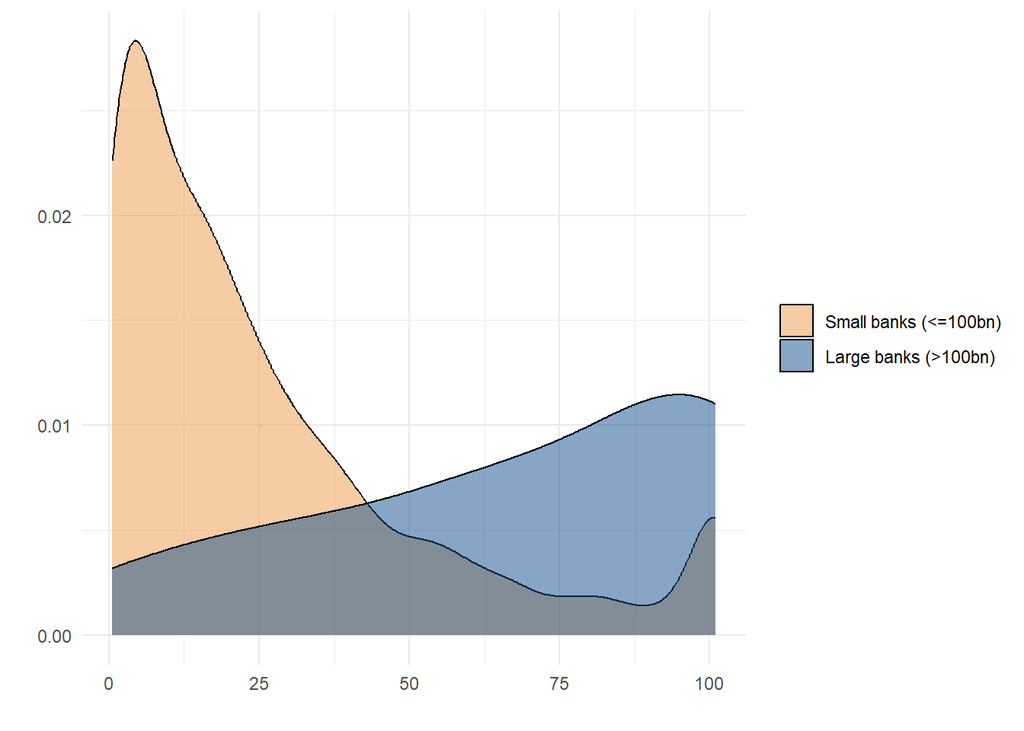

# 4 Branch-Level *log* web_visits_per_deposit_account

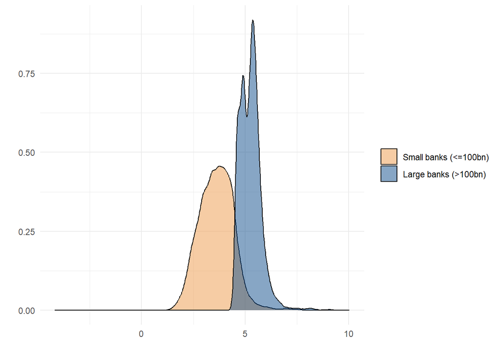

# 5 Closure Regression: pred_log_web_visits_per_deposit_account only

## 5.1 Full Sample

```
Full Sample
======================================================================================================================================================================
                                                                                             Dependent variable:
                                        ------------------------------------------------------------------------------------------------------------------------------
                                                                                                 Linear Prob.
                                           (1)        (2)        (3)       (4)       (5)       (6)       (7)       (8)        (9)      (10)       (11)        (12)
----------------------------------------------------------------------------------------------------------------------------------------------------------------------
pred_log_web_visits_per_deposit_account 0.003***   0.007***     0.001   0.044***  0.052***  0.032***  0.034***   0.036***  0.037***    0.001      0.002       0.001
                                         (0.001)    (0.002)    (0.001)   (0.008)   (0.007)   (0.005)   (0.007)   (0.006)    (0.009)   (0.002)    (0.002)     (0.001)
log(lag_branch_deposit_amount)          -0.021***  -0.027***  -0.018*** -0.014*** -0.017*** -0.017*** -0.020*** -0.021***  -0.036*** -0.027***  -0.023***   -0.019***
                                         (0.001)    (0.002)    (0.001)   (0.001)   (0.001)   (0.002)   (0.002)   (0.002)    (0.005)   (0.003)    (0.003)     (0.002)
deposit_gr_3yrs                           0.000   -0.00000***   0.000   0.000***    0.000   -0.00000  -0.00000   0.00000   -0.00000   0.00000  -0.00000*** -0.00000***
                                         (0.000)    (0.000)    (0.000)   (0.000)   (0.000)  (0.00000) (0.00000) (0.00000)  (0.00000) (0.00000)   (0.000)    (0.00000)
lag_hmda_mtg_amt_gr                      0.00001   -0.0002**   0.00004   -0.0001  -0.00000  -0.0001*   -0.0001  -0.0002***  0.0003*   0.00004    -0.0001    -0.00002
                                        (0.00003)  (0.0001)   (0.00003) (0.0001)  (0.0001)  (0.0001)  (0.0001)   (0.0001)  (0.0001)  (0.0001)   (0.0001)    (0.0001)
lag_cra_loan_amount_amt_lt_1m_gr         0.00000   -0.00000    0.00000   0.00003  -0.00001  -0.0001** -0.00002    0.0001    0.0001   -0.00003    0.00004     0.00002
                                        (0.00001)  (0.0001)   (0.00001) (0.00003) (0.00004) (0.00004) (0.0001)  (0.00003)  (0.00005) (0.00004)  (0.0001)    (0.0001)
lag_county_deposit_hhi                    0.003     0.011*     -0.002    -0.003    -0.001     0.005     0.008     -0.007     0.003    -0.019      0.007     0.026***
                                         (0.003)    (0.006)    (0.003)   (0.007)   (0.009)   (0.008)   (0.007)   (0.006)    (0.010)   (0.013)    (0.009)     (0.009)
log(no_branches_in_zipcode)             -0.039***  -0.035***  -0.043*** -0.070*** -0.071*** -0.062*** -0.050*** -0.036***  -0.039*** -0.015***   -0.001     0.017***
                                         (0.004)    (0.007)    (0.002)   (0.008)   (0.009)   (0.006)   (0.007)   (0.005)    (0.006)   (0.005)    (0.004)     (0.002)
establishments_gr                       -0.069***  -0.178***  -0.031***  -0.027   -0.066***  -0.038   -0.045**   -0.061**  -0.122*** -0.105***  -0.089***   -0.059**
                                         (0.014)    (0.024)    (0.007)   (0.019)   (0.019)   (0.025)   (0.022)   (0.025)    (0.034)   (0.027)    (0.029)     (0.026)
payroll_gr                              -0.005***  -0.006**    -0.003    -0.009*  -0.019**   -0.004    -0.002   -0.027***    0.001    -0.0003     0.005       0.001
                                         (0.002)    (0.003)    (0.003)   (0.005)   (0.008)   (0.006)   (0.007)   (0.010)    (0.010)   (0.008)    (0.008)     (0.006)
same_zip_prior_3yr_branches             0.100***   0.125***   0.083***  0.085***  0.074***  0.082***  0.091***   0.063***  0.153***  0.104***     0.023       0.060
                                         (0.010)    (0.018)    (0.009)   (0.015)   (0.018)   (0.022)   (0.031)   (0.016)    (0.017)   (0.018)    (0.018)     (0.068)
legacy_branch                           0.019***    0.026*    0.019***   0.008*     0.010   0.016***    0.007    0.014***  0.026***  0.026***    -0.0003    -0.037***
                                         (0.004)    (0.013)    (0.002)   (0.005)   (0.007)   (0.006)   (0.008)   (0.005)    (0.008)   (0.009)    (0.008)     (0.009)
----------------------------------------------------------------------------------------------------------------------------------------------------------------------
Sample                                    Full       Large      Small     2015      2016      2017      2018       2019      2020      2021       2022        2023
Bank FE                                     Y          Y          Y         Y         Y         Y         Y         Y          Y         Y          Y           Y
State*Year FE                               Y          Y          Y         Y         Y         Y         Y         Y          Y         Y          Y           Y
Urban/Rural Areas                           Y          Y          Y         Y         Y         Y         Y         Y          Y         Y          Y           Y
Observations                             665,788    271,647    394,141   84,176    82,058    79,907    77,144     74,690    72,489    67,777     64,783      62,764
R2                                        0.060      0.048      0.079     0.153     0.169     0.125     0.104     0.121      0.108     0.109      0.095       0.074
======================================================================================================================================================================
Note:                                                                                                                                      *p<0.1; **p<0.05; ***p<0.01
```

## 5.2 Large Bank Sample

```
Large Banks
======================================================================================================================================
                                                                             Dependent variable:
                                        ----------------------------------------------------------------------------------------------
                                                                                 Linear Prob.
                                            (1)        (2)       (3)        (4)       (5)       (6)        (7)        (8)       (9)
--------------------------------------------------------------------------------------------------------------------------------------
pred_log_web_visits_per_deposit_account  0.044***   0.064***   0.026***  0.031***  0.039***  0.039***     0.001      0.005     0.003
                                          (0.012)    (0.010)   (0.007)    (0.011)   (0.007)   (0.014)    (0.003)    (0.003)   (0.003)
log(lag_branch_deposit_amount)           -0.013***  -0.020*** -0.021***  -0.029*** -0.030*** -0.050***  -0.033***  -0.032*** -0.025***
                                          (0.003)    (0.002)   (0.004)    (0.004)   (0.004)   (0.011)    (0.005)    (0.006)   (0.005)
deposit_gr_3yrs                         -0.00000*** -0.00000   0.00000   -0.00000   0.00001   0.00002  -0.00000***  0.00000  -0.00001
                                          (0.000)   (0.00000) (0.00000)  (0.00000) (0.00001) (0.00002)   (0.000)   (0.00000) (0.00001)
lag_hmda_mtg_amt_gr                       -0.0001   -0.00001  -0.0005*** -0.001*** -0.0004*    0.001     -0.0002   -0.00000   0.0003
                                         (0.0002)   (0.0002)   (0.0002)  (0.0002)  (0.0002)  (0.0003)   (0.0001)   (0.0002)  (0.0004)
lag_cra_loan_amount_amt_lt_1m_gr         -0.00002    0.0001   -0.0002**   -0.0001   0.0001    0.0002    -0.00000    0.0003    -0.0001
                                         (0.0001)   (0.0001)   (0.0001)  (0.0002)  (0.0001)  (0.0002)   (0.0001)   (0.0002)  (0.0002)
lag_county_deposit_hhi                     0.010     -0.021     0.005     0.024**    0.004     0.020     -0.034     0.031*    0.034*
                                          (0.009)    (0.015)   (0.015)    (0.010)   (0.010)   (0.017)    (0.029)    (0.018)   (0.017)
log(no_branches_in_zipcode)              -0.053***  -0.069*** -0.062***  -0.060*** -0.036*** -0.029***   -0.013      0.006   0.029***
                                          (0.011)    (0.016)   (0.010)    (0.015)   (0.009)   (0.009)    (0.009)    (0.006)   (0.004)
establishments_gr                          0.006    -0.122***   -0.074    -0.095*  -0.230*** -0.325***  -0.218***  -0.266*** -0.180***
                                          (0.033)    (0.038)   (0.068)    (0.055)   (0.046)   (0.071)    (0.053)    (0.054)   (0.051)
payroll_gr                               -0.015**   -0.029**   -0.0004     0.005    -0.036*   -0.001      0.007      0.013    -0.007
                                          (0.005)    (0.012)   (0.008)    (0.013)   (0.021)   (0.015)    (0.015)    (0.015)   (0.009)
same_zip_prior_3yr_branches                0.073     -0.002    0.051**    0.062*    0.083**  0.190***   0.140***     0.011     0.070
                                          (0.043)    (0.036)   (0.025)    (0.034)   (0.037)   (0.016)    (0.019)    (0.016)   (0.116)
legacy_branch                             -0.002     -0.017     -0.003    -0.032     0.016    0.045**    0.044**     0.003   -0.057***
                                          (0.006)    (0.014)   (0.014)    (0.034)   (0.024)   (0.021)    (0.017)    (0.016)   (0.017)
--------------------------------------------------------------------------------------------------------------------------------------
Sample                                     2015       2016       2017      2018      2019      2020       2021       2022      2023
Bank FE                                      Y          Y         Y          Y         Y         Y          Y          Y         Y
State*Year FE                                Y          Y         Y          Y         Y         Y          Y          Y         Y
Urban/Rural Areas                            Y          Y         Y          Y         Y         Y          Y          Y         Y
Observations                              33,996     33,597     33,004    31,772    30,607    29,350     27,244     26,412    25,665
R2                                         0.073      0.083     0.064      0.059     0.069     0.071      0.064      0.056     0.031
======================================================================================================================================
Note:                                                                                                      *p<0.1; **p<0.05; ***p<0.01
```

## 5.3 Small Bank Sample

```
Small Banks
=====================================================================================================================================
                                                                             Dependent variable:
                                        ---------------------------------------------------------------------------------------------
                                                                                Linear Prob.
                                           (1)       (2)       (3)       (4)       (5)       (6)       (7)        (8)         (9)
-------------------------------------------------------------------------------------------------------------------------------------
pred_log_web_visits_per_deposit_account 0.048***  0.039***  0.036***  0.033***  0.032***  0.036***    0.001     -0.0003      0.001
                                         (0.009)   (0.009)   (0.009)   (0.009)   (0.009)   (0.012)   (0.002)    (0.002)     (0.001)
log(lag_branch_deposit_amount)          -0.015*** -0.015*** -0.015*** -0.014*** -0.014*** -0.028*** -0.023***  -0.016***   -0.015***
                                         (0.001)   (0.001)   (0.002)   (0.001)   (0.001)   (0.002)   (0.002)    (0.002)     (0.002)
deposit_gr_3yrs                         0.000***    0.000   -0.00000   0.00000   0.00000  -0.00000*  0.00000  -0.00000*** -0.00000***
                                         (0.000)   (0.000)  (0.00000) (0.00000) (0.00000) (0.00000) (0.00000)   (0.000)    (0.00000)
lag_hmda_mtg_amt_gr                     -0.00004  -0.00001   0.00000   0.00002  -0.0002**  0.0001    0.0002*    -0.0001     -0.0001
                                        (0.0001)  (0.0001)  (0.0001)  (0.0001)  (0.0001)  (0.0001)  (0.0001)   (0.0001)    (0.0001)
lag_cra_loan_amount_amt_lt_1m_gr         0.0001   -0.00004  -0.00003   0.00003   0.00002   0.0001   -0.00004   -0.00000     0.0001
                                        (0.00004) (0.00004) (0.00004) (0.00004) (0.00003) (0.00005) (0.00005)  (0.00005)   (0.00004)
lag_county_deposit_hhi                  -0.018**    0.014     0.003    -0.001    -0.010*   -0.012    -0.006     -0.013*     0.020**
                                         (0.009)   (0.009)   (0.008)   (0.008)   (0.006)   (0.009)   (0.009)    (0.008)     (0.010)
log(no_branches_in_zipcode)             -0.090*** -0.073*** -0.060*** -0.041*** -0.036*** -0.051*** -0.018***  -0.007**    0.008***
                                         (0.007)   (0.006)   (0.006)   (0.005)   (0.005)   (0.006)   (0.005)    (0.003)     (0.002)
establishments_gr                        -0.043*  -0.050**   -0.020    -0.026     0.004    -0.047*  -0.055**    -0.011      -0.005
                                         (0.022)   (0.020)   (0.018)   (0.020)   (0.023)   (0.025)   (0.025)    (0.018)     (0.019)
payroll_gr                               -0.008    -0.012    -0.005    -0.006    -0.018*    0.004    -0.004     -0.002       0.008
                                         (0.007)   (0.011)   (0.008)   (0.009)   (0.010)   (0.012)   (0.009)    (0.008)     (0.008)
same_zip_prior_3yr_branches             0.095***  0.083***  0.087***   0.091**  0.055***  0.115***   0.041**    0.064**      0.034
                                         (0.015)   (0.017)   (0.027)   (0.038)   (0.015)   (0.022)   (0.017)    (0.028)     (0.029)
legacy_branch                            0.012**  0.015***  0.018***   0.011**  0.012***  0.028***   0.018**    -0.003     -0.022***
                                         (0.005)   (0.005)   (0.005)   (0.005)   (0.005)   (0.008)   (0.007)    (0.005)     (0.005)
-------------------------------------------------------------------------------------------------------------------------------------
Sample                                    2015      2016      2017      2018      2019      2020      2021       2022        2023
Bank FE                                     Y         Y         Y         Y         Y         Y         Y          Y           Y
State*Year FE                               Y         Y         Y         Y         Y         Y         Y          Y           Y
Urban/Rural Areas                           Y         Y         Y         Y         Y         Y         Y          Y           Y
Observations                             50,180    48,461    46,903    45,372    44,083    43,139    40,533     38,371      37,099
R2                                        0.208     0.248     0.187     0.174     0.191     0.153     0.169      0.154       0.142
=====================================================================================================================================
Note:                                                                                                     *p<0.1; **p<0.05; ***p<0.01
```

# 6 Closure Regression: pred_log_web_visits_per_deposit_account + df_per_dollar

```
Full Sample
======================================================================================================================================================================
                                                                                             Dependent variable:
                                        ------------------------------------------------------------------------------------------------------------------------------
                                                                                                 Linear Prob.
                                           (1)        (2)        (3)       (4)       (5)       (6)       (7)       (8)        (9)      (10)       (11)        (12)
----------------------------------------------------------------------------------------------------------------------------------------------------------------------
df_per_dollar                           -0.733***  -1.175***  -0.172**  -0.807*** -0.662*** -0.817*** -0.665*** -0.571***  -1.274*** -0.487**   -0.834***   -0.613***
                                         (0.130)    (0.160)    (0.087)   (0.192)   (0.195)   (0.147)   (0.244)   (0.169)    (0.271)   (0.216)    (0.206)     (0.227)
pred_log_web_visits_per_deposit_account  -0.003*    -0.0005    -0.0001  0.038***  0.047***  0.027***  0.029***   0.032***    0.017    -0.003    -0.005***    -0.003
                                         (0.001)    (0.002)    (0.001)   (0.008)   (0.007)   (0.005)   (0.007)   (0.006)    (0.011)   (0.002)    (0.002)     (0.002)
log(lag_branch_deposit_amount)          -0.022***  -0.029***  -0.018*** -0.015*** -0.017*** -0.018*** -0.021*** -0.021***  -0.037*** -0.027***  -0.024***   -0.019***
                                         (0.001)    (0.002)    (0.001)   (0.002)   (0.001)   (0.002)   (0.003)   (0.003)    (0.005)   (0.003)    (0.003)     (0.002)
deposit_gr_3yrs                           0.000   -0.00000***   0.000   0.000***    0.000   -0.00000  -0.00000   0.00000   -0.00000   0.00000  -0.00000*** -0.00000***
                                         (0.000)    (0.000)    (0.000)   (0.000)   (0.000)  (0.00000) (0.00000) (0.00000)  (0.00000) (0.00000)   (0.000)    (0.00000)
lag_hmda_mtg_amt_gr                      0.00001    -0.0001    0.00004   0.00003  -0.00004   -0.0001  -0.00002  -0.0002***  0.0001    0.00002    0.00003     0.0001
                                        (0.00003)  (0.0001)   (0.00003) (0.0001)  (0.0001)  (0.0001)  (0.0001)   (0.0001)  (0.0001)  (0.0001)   (0.0001)    (0.0001)
lag_cra_loan_amount_amt_lt_1m_gr        -0.00000   -0.00001    0.00000   0.00003  -0.00001  -0.0001** -0.00002   0.0001*    0.0001   -0.00005    0.00005     0.00003
                                        (0.00001)  (0.0001)   (0.00001) (0.00003) (0.00004) (0.00004) (0.0001)  (0.00004)  (0.00005) (0.00004)  (0.0001)    (0.0001)
lag_county_deposit_hhi                    0.001      0.005     -0.002    -0.006    -0.003     0.002     0.006     -0.009    -0.001    -0.020      0.004     0.025***
                                         (0.003)    (0.006)    (0.003)   (0.007)   (0.009)   (0.008)   (0.007)   (0.005)    (0.010)   (0.012)    (0.009)     (0.009)
log(no_branches_in_zipcode)             -0.039***  -0.037***  -0.043*** -0.071*** -0.072*** -0.063*** -0.051*** -0.037***  -0.040*** -0.016***   -0.001     0.017***
                                         (0.004)    (0.007)    (0.002)   (0.008)   (0.009)   (0.006)   (0.007)   (0.005)    (0.006)   (0.005)    (0.004)     (0.002)
establishments_gr                       -0.072***  -0.184***  -0.032*** -0.038**  -0.072***  -0.040   -0.051**   -0.066**  -0.141*** -0.101***  -0.087***   -0.058**
                                         (0.014)    (0.024)    (0.007)   (0.019)   (0.019)   (0.025)   (0.022)   (0.026)    (0.036)   (0.026)    (0.028)     (0.026)
payroll_gr                              -0.007***  -0.009***   -0.004   -0.010**  -0.020**   -0.006    -0.003   -0.029***   -0.004    -0.003      0.005       0.002
```

[output cut: 14 more lines]

# 7 Regressions with more controls: only 2022 and 2023

The following regressions include the following additional controls:

1. log(median time spent by visitors at the branch in 2019)
2. log(number of visitors to the branch in 2019)
3. Change in number of visitors from 2019 to 2021. Measured as visitors in 2021/visitors in 2019-1
4. Change in time spent at the branch from 2019 to 2021. Measured as time in 2021/time in 2019-1

Note that due to the poor match of cell phone data and closed branches in years prior to 2022 (there is a plot in dropbox), **the regression is restricted only to years 2022 and 2023.**

```
Full Sample
======================================================================================================
                                                             Dependent variable:
                                        --------------------------------------------------------------
                                                 Full                 Large               Small
                                            (1)        (2)        (3)       (4)       (5)       (6)
------------------------------------------------------------------------------------------------------
df_per_dollar                            -0.597***  -0.400***  -0.976*** -0.646***  -0.176*   -0.069
                                          (0.140)    (0.122)    (0.172)   (0.150)   (0.103)   (0.105)
pred_log_web_visits_per_deposit_account  -0.004**    -0.003**   -0.004    -0.005*   -0.002    -0.002
                                          (0.001)    (0.001)    (0.003)   (0.003)   (0.001)   (0.001)
log(lag_branch_deposit_amount)           -0.020***  -0.021***  -0.027*** -0.029*** -0.013*** -0.014***
                                          (0.003)    (0.003)    (0.005)   (0.005)   (0.001)   (0.002)
deposit_gr_3yrs                         -0.00000*** -0.00000** -0.00000  -0.00000   -0.000    -0.000
                                          (0.000)    (0.000)   (0.00000) (0.00000)  (0.000)   (0.000)
lag_hmda_mtg_amt_gr                      -0.00002    -0.00003   0.00002   -0.0001  -0.00004  -0.00003
                                         (0.0001)    (0.0001)  (0.0002)  (0.0002)  (0.0001)  (0.0001)
lag_cra_loan_amount_amt_lt_1m_gr         -0.00000    -0.00001   0.00001  -0.00004   0.00000   0.00000
                                         (0.00004)  (0.00004)  (0.0001)  (0.0001)  (0.00004) (0.00004)
lag_county_deposit_hhi                   0.014***    0.012**    0.018**   0.014*     0.007     0.006
                                          (0.005)    (0.005)    (0.008)   (0.008)   (0.006)   (0.006)
log(no_branches_in_zipcode)              0.010***    0.010***  0.017***  0.016***    0.002     0.002
                                          (0.002)    (0.002)    (0.003)   (0.003)   (0.002)   (0.002)
establishments_gr                        -0.082***  -0.059***  -0.156*** -0.104**   -0.027    -0.015
                                          (0.023)    (0.021)    (0.038)   (0.038)   (0.017)   (0.017)
payroll_gr                                 0.003      0.001      0.001    -0.005     0.004     0.005
                                          (0.005)    (0.005)    (0.006)   (0.006)   (0.008)   (0.008)
same_zip_prior_3yr_branches                0.034      0.034      0.034     0.034     0.031     0.031
                                          (0.038)    (0.038)    (0.056)   (0.056)   (0.020)   (0.020)
legacy_branch                            -0.014**    -0.012**  -0.021**   -0.019*   -0.005    -0.005
                                          (0.005)    (0.005)    (0.010)   (0.009)   (0.004)   (0.004)
log(time_spent_min_2019)                             0.006***            0.010***            0.003***
                                                     (0.001)              (0.001)             (0.001)
log(no_of_visitors_2019)                              0.003                0.005              0.002*
                                                     (0.002)              (0.004)             (0.001)
I(chg_no_of_visitors - 1)                             -0.008              -0.010             -0.005**
                                                     (0.006)              (0.011)             (0.002)
I(chg_time_spent - 1)                                0.002***            0.003***             0.001*
                                                     (0.001)              (0.001)            (0.0005)
------------------------------------------------------------------------------------------------------
Bank FE                                      Y          Y          Y         Y         Y         Y
State*Year FE                                Y          Y          Y         Y         Y         Y
Urban/Rural Areas                            Y          Y          Y         Y         Y         Y
Observations                              95,956      95,688    45,472    45,401    50,484    50,287
R2                                         0.058      0.061      0.033     0.039     0.109     0.110
======================================================================================================
Note:                                                                      *p<0.1; **p<0.05; ***p<0.01
```

```
Full Sample
===========================================================================================================================
                                                                        Dependent variable:
                                        -----------------------------------------------------------------------------------
                                                      Large Banks                               Small Banks
                                           (1)       (2)       (3)       (4)       (5)       (6)        (7)         (8)
---------------------------------------------------------------------------------------------------------------------------
df_per_dollar                           -1.192*** -0.890*** -0.800**   -0.443    -0.047     0.023     -0.332      -0.193
                                         (0.257)   (0.234)   (0.285)   (0.272)   (0.194)   (0.193)    (0.207)     (0.199)
pred_log_web_visits_per_deposit_account  -0.005*   -0.006*   -0.003    -0.004    -0.003    -0.003     -0.002      -0.0004
                                         (0.003)   (0.003)   (0.004)   (0.004)   (0.002)   (0.002)    (0.002)     (0.002)
log(lag_branch_deposit_amount)          -0.025*** -0.027*** -0.028*** -0.030*** -0.012*** -0.013***  -0.014***   -0.015***
                                         (0.006)   (0.007)   (0.005)   (0.005)   (0.002)   (0.002)    (0.002)     (0.002)
deposit_gr_3yrs                          0.00000   0.00000  -0.00001  -0.00000   -0.000    -0.000   -0.00000*** -0.00000***
                                        (0.00000) (0.00000) (0.00001) (0.00001)  (0.000)   (0.000)   (0.00000)   (0.00000)
lag_hmda_mtg_amt_gr                      -0.0001   -0.0002   0.0005    0.0004    -0.0001   -0.0001    0.0001      0.0001
                                        (0.0002)  (0.0002)  (0.0005)  (0.0005)  (0.0001)  (0.0001)   (0.0001)    (0.0001)
lag_cra_loan_amount_amt_lt_1m_gr         0.0002    0.0001    -0.0001   -0.0002  -0.00003  -0.00003    0.00004     0.00003
                                        (0.0001)  (0.0001)  (0.0002)  (0.0002)  (0.00005) (0.00005)  (0.0001)    (0.0001)
lag_county_deposit_hhi                  -0.00001   -0.004    0.034**   0.031*    -0.011    -0.012     0.025*      0.024*
                                         (0.015)   (0.016)   (0.016)   (0.016)   (0.009)   (0.009)    (0.013)     (0.013)
log(no_branches_in_zipcode)               0.003     0.003   0.029***  0.029***   -0.005    -0.005    0.008***    0.008***
                                         (0.005)   (0.005)   (0.003)   (0.003)   (0.003)   (0.003)    (0.003)     (0.003)
establishments_gr                       -0.150*** -0.105**  -0.156*** -0.099**   -0.007     0.004     -0.044*     -0.033
                                         (0.040)   (0.040)   (0.049)   (0.045)   (0.020)   (0.019)    (0.025)     (0.025)
payroll_gr                                0.006     0.001    -0.005    -0.011     0.002     0.002      0.007       0.007
                                         (0.014)   (0.015)   (0.008)   (0.008)   (0.009)   (0.009)    (0.011)     (0.011)
same_zip_prior_3yr_branches               0.007     0.008     0.088     0.086     0.018     0.018      0.052       0.052
                                         (0.014)   (0.015)   (0.143)   (0.142)   (0.015)   (0.014)    (0.039)     (0.038)
legacy_branch                             0.011     0.014   -0.055*** -0.051***  -0.001    0.0001    -0.015**    -0.015**
                                         (0.014)   (0.013)   (0.015)   (0.015)   (0.005)   (0.005)    (0.006)     (0.006)
log(time_spent_min_2019)                          0.009***            0.011***            0.002***               0.003***
                                                   (0.002)             (0.002)             (0.001)                (0.001)
log(no_of_visitors_2019)                            0.004               0.006              0.004**                -0.0003
                                                   (0.005)             (0.004)             (0.001)                (0.001)
I(chg_no_of_visitors - 1)                          -0.010              -0.011              -0.001                -0.009***
                                                   (0.014)             (0.012)             (0.003)                (0.003)
I(chg_time_spent - 1)                               0.002              0.004**              0.001                  0.001
                                                   (0.002)             (0.002)             (0.001)                (0.001)
---------------------------------------------------------------------------------------------------------------------------
Sample                                    2022      2022      2023      2023      2022      2022       2023        2023
Bank FE                                     Y         Y         Y         Y         Y         Y          Y           Y
State*Year FE                               Y         Y         Y         Y         Y         Y          Y           Y
Urban/Rural Areas                           Y         Y         Y         Y         Y         Y          Y           Y
Observations                             22,880    22,845    22,592    22,556    25,661    25,562     24,823      24,725
R2                                        0.046     0.050     0.032     0.038     0.165     0.167      0.132       0.134
===========================================================================================================================
Note:                                                                                           *p<0.1; **p<0.05; ***p<0.01
```